# WeConnect Flight analysis

Noel

## Loading the files needed for the analysis and initial descriptive diagnosis

In the following code, the .csv files are loaded, the columns are labeled with headers, then joined together to create a table with all of the information.

```r
#loading the csv files
flights <- read.csv("C:/Myfiles/Misoiscool/WeConnect/flight-dataset/flights-small.csv", header = FALSE)
carriers <- read.csv("C:/Myfiles/Misoiscool/WeConnect/flight-dataset/carriers.csv", header = FALSE)
months <- read.csv("C:/Myfiles/Misoiscool/WeConnect/flight-dataset/months.csv", header = FALSE)
weekdays <- read.csv("C:/Myfiles/Misoiscool/WeConnect/flight-dataset/weekdays.csv", header = FALSE)
#naming the columns
colnames(flights) <- c("fid","month_id","day_of_month","day_of_week_id","carrier_id","flight_num","origin_city","origin_state","dest_city","dest_state","departure_delay","taxi_out","arrival_delay","canceled","actual_time","distance","capacity","price")
colnames(carriers) <- c("carrier_id", "carrier_name")
colnames(months) <- c("month_id", "month")
colnames(weekdays) <- c("day_of_week_id", "day_of_week")
#joining the tables
flightswcar <- merge(flights, carriers)
flightswmonthcar <- merge(flightswcar, months, type = "inner")
flightsall <- merge(flightswmonthcar, weekdays, type = "inner")

#Remove from environment
remove(carriers, flights, months, weekdays, flightswcar, flightswmonthcar)
```

This is just an initial diagnostic with summary information from the dataset. For the purposes of the following questions, this information is not needed. This code also lists the unique airlines that are included in this dataset.

```r
#inital diagnostic
summary(flightsall)
```

```
##  day_of_week_id     month_id   carrier_id          fid           day_of_month
##  Min.   :1.000   Min.   :7   WN     :202376   Min.   :      1   Min.   : 1.00
##  1st Qu.:2.000   1st Qu.:7   AA     :141160   1st Qu.: 287170   1st Qu.: 8.00
##  Median :4.000   Median :7   DL     :139025   Median : 574338   Median :16.00
##  Mean   :4.195   Mean   :7   OO     : 96703   Mean   : 574338   Mean   :16.12
##  3rd Qu.:6.000   3rd Qu.:7   UA     : 88651   3rd Qu.: 861507   3rd Qu.:24.00
##  Max.   :7.000   Max.   :7   EV     : 77108   Max.   :1148675   Max.   :31.00
##                              (Other):403652
##    flight_num                 origin_city         origin_state
##  Min.   :   1   Chicago IL          : 73317   California:135483
##  1st Qu.: 642   Atlanta GA          : 71955   Texas     :130220
##  Median :1531   Dallas/Fort Worth TX: 50288   Florida   : 76324
##  Mean   :2088   Houston TX          : 42634   Illinois  : 75925
##  3rd Qu.:3215   Los Angeles CA      : 39536   Georgia   : 75423
##  Max.   :9542   New York NY         : 38690   New York  : 52823
##                 (Other)             :832255   (Other)   :602477
##                 dest_city           dest_state     departure_delay
##  Chicago IL          : 73279   California:135483   Min.   :-1164.00
##  Atlanta GA          : 71319   Texas     :130286   1st Qu.:   -4.00
##  Dallas/Fort Worth TX: 50294   Florida   : 76409   Median :    0.00
##  Houston TX          : 42663   Illinois  : 75914   Mean   :   12.76
##  Los Angeles CA      : 39539   Georgia   : 74730   3rd Qu.:   12.00
##  New York NY         : 38695   New York  : 52881   Max.   : 1732.00
##  (Other)             :832886   (Other)   :602972
##     taxi_out      arrival_delay        canceled        actual_time
##  Min.   :  0.00   Min.   : -76.00   Min.   :0.00000   Min.   :  0.0
##  1st Qu.: 10.00   1st Qu.: -10.00   1st Qu.:0.00000   1st Qu.: 76.0
##  Median : 14.00   Median :  -1.00   Median :0.00000   Median :111.0
##  Mean   : 16.24   Mean   :  11.04   Mean   :0.01624   Mean   :130.1
##  3rd Qu.: 19.00   3rd Qu.:  14.00   3rd Qu.:0.00000   3rd Qu.:162.0
##  Max.   :362.00   Max.   :1735.00   Max.   :1.00000   Max.   :761.0
##
##     distance         capacity          price
##  Min.   :  31.0   Min.   : 0.000   Min.   : 100.0
##  1st Qu.: 338.0   1st Qu.: 5.000   1st Qu.: 324.0
##  Median : 606.0   Median :10.000   Median : 549.0
##  Mean   : 783.3   Mean   : 9.499   Mean   : 549.4
##  3rd Qu.:1011.0   3rd Qu.:14.000   3rd Qu.: 774.0
##  Max.   :4983.0   Max.   :19.000   Max.   :1000.0
##
##                    carrier_name         month            day_of_week
##  Southwest Airlines Co.  :202376   July    :1148675   Friday   :190880
##  American Airlines Inc.  :141160   April   :      0   Sunday   :181916
##  Delta Air Lines Inc.    :139025   August  :      0   Saturday :180157
##  SkyWest Airlines Inc.   : 96703   December:      0   Wednesday:153154
##  United Air Lines Inc.   : 88651   February:      0   Thursday :152701
##  ExpressJet Airlines Inc.: 77108   January :      0   Tuesday  :150280
##  (Other)                 :403652   (Other) :      0   (Other)  :139587
```

```r
#finding which carriers are listed in the flight dataset
unique(flightsall$carrier_id)
```

```
##  [1] WN OO US AS DL UA MQ EV B6 VX XE NK HA NW AA CO OH FL HP F9 DH TZ
## 22 Levels: AA AS B6 CO DH DL EV F9 FL HA HP MQ NK NW OH OO TZ UA US VX ... XE
```

```r
unique(flightsall$carrier_name) #22 airlines total
```

```
##  [1] Southwest Airlines Co.
##  [2] SkyWest Airlines Inc.
##  [3] US Airways Inc.
##  [4] Alaska Airlines Inc.
##  [5] Delta Air Lines Inc.
##  [6] United Air Lines Inc.
##  [7] Envoy Air
##  [8] ExpressJet Airlines Inc.
##  [9] JetBlue Airways
## [10] Virgin America
## [11] ExpressJet Airlines Inc. (1)
## [12] Spirit Air Lines
## [13] Hawaiian Airlines Inc.
## [14] Northwest Airlines Inc.
## [15] American Airlines Inc.
## [16] Continental Air Lines Inc.
## [17] Comair Inc.
## [18] AirTran Airways Corporation
## [19] America West Airlines Inc. (Merged with US Airways 9/05. Stopped reporting 10/07.)
## [20] Frontier Airlines Inc.
## [21] Independence Air
## [22] ATA Airlines d/b/a ATA
## 1593 Levels: 40-Mile Air A/S Conair AAA-Action Air Carrier Inc. ... Zuliana De Aviacion
```

## Finding the maximum price for flights between Seattle and NYC (nonstop)

The following code finds the maximum price of a flight from Seattle to New York City or New York City to Seattle on a nonstop flight.

```r
#######Retrieving the max price of flights from Seattle to NY and NY to Seattle on a nonstop flight
#separating table from flightsall with just direct flights from Seattle to NY
flightsSEANY <- subset(flightsall, origin_city == "Seattle WA" & dest_city == "New York NY" | origin_city == "New York NY" & dest_city == "Seattle WA")
priceflights <- aggregate(flightsSEANY$price, list(flightsSEANY$carrier_name), function(x) max(x))
colnames(priceflights) <- c("Airline", "Price")
library(gridExtra)
library(grid)
head(priceflights)
```

```
##                  Airline Price
## 1 American Airlines Inc.   991
## 2   Delta Air Lines Inc.   999
## 3        JetBlue Airways   996
```

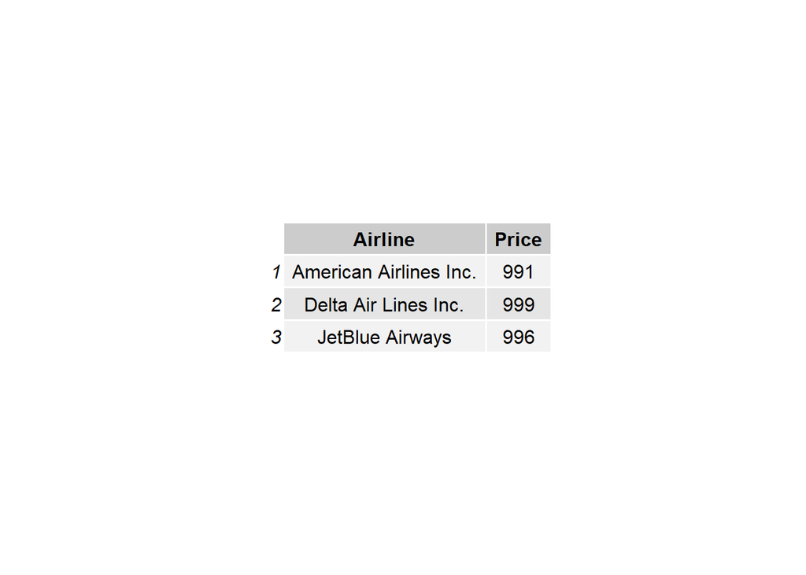

```r
grid.table(head(priceflights))
```

```r
#######
```

This table shows the most expensive tickets from American Airlines, Delta, and JetBlue.

## Finding the maximum price for flights between Seattle and NYC with one stop

The following code finds the maximum price of a flight from Seattle to New York City or New York City to Seattle with one layover during the flight.

```r
#######Calculating the max price of flights from Seattle to NY and NY to Seattle with one stop
#flights out of Seattle
flightsoutofSEA <- flightsall %>%
  filter(origin_city == "Seattle WA") %>%
  select(carrier_name, origin_city, dest_city, price)
#flights going into NY
flightsintoNYC <- flightsall %>%
  filter(dest_city == "New York NY") %>%
  select(carrier_name,origin_city, dest_city, price)
#merging the two tables together
flightsSEANYC <- merge(flightsoutofSEA, flightsintoNYC, by.x = c("carrier_name", "dest_city"), by.y = c("carrier_name", "origin_city"), type = "inner")
#getting the sum of the prices
flightsSEANYConestop <- cbind(flightsSEANYC, rowSums(flightsSEANYC[,c(4,6)]))
#renaming the columns
colnames(flightsSEANYConestop) <- c("carrier_name", "stop", "origin", "maxprice1stleg", "dest", "maxprice2ndleg", "totprice")
#getting the max price for the one-stop flights by airline
maxpriceSEANYConestopmax <- flightsSEANYConestop %>%
  group_by(carrier_name) %>%
  summarise(maxprice = max(totprice))

#flights out of NY
flightsoutofNYC <- flightsall %>%
  filter(origin_city == "New York NY") %>%
  select(carrier_name, origin_city, dest_city, price)
#flights going into Seattle
flightsintoSEA <- flightsall %>%
  filter(dest_city == "Seattle WA") %>%
  select(carrier_name,origin_city, dest_city, price)
#merging the two tables together
flightsNYCSEA <- merge(flightsoutofNYC, flightsintoSEA, by.x = c("carrier_name", "dest_city"), by.y = c("carrier_name", "origin_city"), type = "inner")
#getting the sum of the pirces
flightsNYCSEAonestop <- cbind(flightsNYCSEA, rowSums(flightsNYCSEA[,c(4,6)]))
#renaming the columns
colnames(flightsNYCSEAonestop) <- c("carrier_name", "stop", "origin", "maxprice1stleg", "dest", "maxprice2ndleg", "totprice")
#getting the max prices for the one-stop flights by airline
maxpriceNYCSEAonestopmax <- flightsNYCSEAonestop %>%
  group_by(carrier_name) %>%
  summarise(maxprice = max(totprice))
#merging the two max price tables together to compare prices by airlines
maxpriceonestop <- merge(maxpriceSEANYConestopmax, maxpriceNYCSEAonestopmax, by = "carrier_name", type = "inner")
colnames(maxpriceonestop) <- c("carrier_name", "SEA-NYC", "NYC-SEA")
maxpriceonestop$High_price <- pmax(maxpriceonestop$`SEA-NYC`, maxpriceonestop$`NYC-SEA`)
maxpriceonestopdesc <- arrange(maxpriceonestop, desc(High_price))
kable(maxpriceonestopdesc)
```

| carrier_name | SEA-NYC | NYC-SEA | High_price |
| --- | --- | --- | --- |
| American Airlines Inc. | 1998 | 1996 | 1998 |
| Delta Air Lines Inc. | 1997 | 1998 | 1998 |
| Southwest Airlines Co. | 1998 | 1997 | 1998 |
| United Air Lines Inc. | 1998 | 1997 | 1998 |
| Frontier Airlines Inc. | 1994 | 1997 | 1997 |
| Northwest Airlines Inc. | 1993 | 1997 | 1997 |
| US Airways Inc. | 1996 | 1997 | 1997 |
| Virgin America | 1996 | 1993 | 1996 |
| America West Airlines Inc. (Merged with US Airways 9/05. Stopped reporting 10/07.) | 1991 | 1994 | 1994 |
| Continental Air Lines Inc. | 1994 | 1989 | 1994 |
| JetBlue Airways | 1992 | 1994 | 1994 |
| Independence Air | 1938 | 1992 | 1992 |
| Hawaiian Airlines Inc. | 1967 | 1985 | 1985 |

```r
#######
```

This table shows the list of carriers with descending maximum priced airline tickets between Seattle and NYC. American Airlines, Delta, Southwest, and United airlines all have the most expensive tickets with one layover at a price of 1998.

## Finding the maximum price for flights between Seattle and NYC with two stops

The following code finds the maximum price of a flight from Seattle to New York City or New York City to Seattle with two layovers during the flight.

```r
#######Calculating the max price for flights from Seattle to NY and NY to Seattle with two stops
#filtering all of the city combinations that don't include Seattle or NYC as an origin or destination
#these data were groupd by carrier name, origin city, and the destination city
allbutSEANYC <- flightsall %>%
  filter(dest_city != "New York NY" & dest_city != "Seattle WA" & origin_city != "New York NY" & origin_city != "Seattle WA") %>%
  select(carrier_name, origin_city, dest_city, price) %>%
  group_by(carrier_name, origin_city, dest_city) %>%
  summarise(maxprice = max(price))
#merging the previous city combinations (2nd leg of flight) with flights that had a first stop departing from Seattle
flightsSEANYCtwostop <- merge(flightsoutofSEA, allbutSEANYC, by.x = c("carrier_name", "dest_city"), by.y = c("carrier_name", "origin_city"), type = "inner")
#naming the columns
colnames(flightsSEANYCtwostop) <- c("carrier_name", "stop_one", "origin_city", "price_leg_one", "stop_two", "price_leg_two")
#merging the table for the flights from Seattle with the two stops, then the flight into NYC
flightsSEANYCfinal <- merge(flightsSEANYCtwostop, flightsintoNYC, by.x = c("carrier_name", "stop_two"), by.y = c("carrier_name", "origin_city"), type = "inner")
#getting the sum of the prices for a total price for the three-leg flight
flightsSEANYCfinalsum <- cbind(flightsSEANYCfinal, rowSums(flightsSEANYCfinal[,c(5,6,8)]))
colnames(flightsSEANYCfinalsum) <- c("carrier_name", "stop_one", "origin_city", "price_leg_one", "stop_two", "price_leg_two", "dest_city", "price", "tot_price")
#finding the maximum price of the flights by carrier
maxpriceSEANYCtwostop <- flightsSEANYCfinalsum %>%
  group_by(carrier_name) %>%
  summarise(maxprice = max(tot_price))
#doing the reverse
#merging the previous city combinations (2nd leg of flight) with flights that had a first stop departing from Seattle
flightsNYCSEAtwostop <- merge(flightsoutofNYC, allbutSEANYC, by.x = c("carrier_name", "dest_city"), by.y = c("carrier_name", "origin_city"), type = "inner")
colnames(flightsNYCSEAtwostop) <- c("carrier_name", "stop_one", "origin_city", "price_leg_one", "stop_two", "price_leg_two")
flightsNYCSEAfinal <- merge(flightsNYCSEAtwostop, flightsintoSEA, by.x = c("carrier_name", "stop_two"), by.y = c("carrier_name", "origin_city"), type = "inner")
flightsNYCSEAfinalsum <- cbind(flightsNYCSEAfinal, rowSums(flightsNYCSEAfinal[,c(5,6,8)]))
colnames(flightsNYCSEAfinalsum) <- c("carrier_name", "stop_one", "origin_city", "price_leg_one", "stop_two", "price_leg_two", "dest_city", "price", "tot_price")
maxpriceNYCSEAtwostop <- flightsNYCSEAfinalsum %>%
  group_by(carrier_name) %>%
  summarise(maxprice = max(tot_price))
#merging the two max price tables together to compare prices by airlines
maxpricetwostopNYCSEA <- merge(maxpriceSEANYCtwostop, maxpriceNYCSEAtwostop, by = "carrier_name", type = "inner")
maxpricetwostopNYCSEA$High_price <- pmax(maxpricetwostopNYCSEA$maxprice.x, maxpricetwostopNYCSEA$maxprice.y)
maxpricetwostopNYCSEAdesc <- arrange(maxpricetwostopNYCSEA, desc(High_price))
kable(maxpricetwostopNYCSEAdesc)
```

| carrier_name | maxprice.x | maxprice.y | High_price |
| --- | --- | --- | --- |
| United Air Lines Inc. | 2998 | 2997 | 2998 |
| American Airlines Inc. | 2997 | 2996 | 2997 |
| Delta Air Lines Inc. | 2996 | 2997 | 2997 |
| US Airways Inc. | 2995 | 2997 | 2997 |
| Southwest Airlines Co. | 2996 | 2996 | 2996 |
| JetBlue Airways | 2995 | 2995 | 2995 |
| Northwest Airlines Inc. | 2992 | 2995 | 2995 |
| America West Airlines Inc. (Merged with US Airways 9/05. Stopped reporting 10/07.) | 2991 | 2993 | 2993 |
| Continental Air Lines Inc. | 2990 | 2993 | 2993 |
| Virgin America | 2993 | 2990 | 2993 |
| Frontier Airlines Inc. | 2968 | 2951 | 2968 |
| Hawaiian Airlines Inc. | 2951 | 2948 | 2951 |
| ExpressJet Airlines Inc. | 2943 | 2929 | 2943 |

This table shows the list of carriers with descending maximum priced airline tickets between Seattle and NYC. United has the most most expensive ticket with two layovers at a price of 2998.

## Finding the average cost of a ticket by day of week for direct flights from Seattle to Boston on Alaska Airlines

The following code finds the average cost of a ticket by each day of the week for direct flights from Seattle to Boston on Alaska Airlines Inc.

```r
#############
SEABOSAK <- flightsall %>%
  filter(origin_city == "Seattle WA" & dest_city == "Boston MA" & carrier_name == "Alaska Airlines Inc.") %>% #filtering out all flights by Alaska Airlines with an origination city of Seattle and destination city of Boston
  group_by(day_of_week) %>% #grouping this by day of the week
  select(carrier_name, day_of_week, price) %>%
  summarise(average_price = mean(price))
kable(SEABOSAK)
```

| day_of_week | average_price |
| --- | --- |
| Friday | 536.80 |
| Monday | 519.20 |
| Saturday | 725.16 |
| Sunday | 563.08 |
| Thursday | 524.95 |
| Tuesday | 544.50 |
| Wednesday | 538.55 |

This table shows that the average price of tickets for the majority of the days of the week is in the lower-500s. The price of tickets on Saturday is 725, which is roughly 200 more than the average price of tickets during the rest of the week.

## Finding the specific flights that maximize the distance traveled in the least amount of time from Seattle.

The code that follows investigates the trips that allow for travel as far as possible in the least amount of time from Seattle.

```r
#############
#filtering out those flights that originate in Seattle
SEAtimefar <- flightsall %>%
  filter(origin_city == "Seattle WA") %>%
  select(carrier_name, fid, origin_city, dest_city, actual_time, distance)
#adding a column that calculates the distance per unit time
SEAtimefar$distance_over_time <- SEAtimefar$distance / SEAtimefar$actual_time
max(SEAtimefar$distance_over_time)
```

```
## [1] Inf
```

```r
#there are some inconsistencies in the data, so this will be done with averages based on destination
SEAtimefaravg <- flightsall %>%
  filter(origin_city == "Seattle WA" & actual_time > 0)
SEAtimefaravg$distance_over_time <- SEAtimefaravg$distance / SEAtimefaravg$actual_time
SEAtimefaravg.1 <- SEAtimefaravg %>%
  group_by(carrier_name, dest_city) %>%
  summarise(average_dist_time = mean(distance_over_time))
top <- SEAtimefaravg.1 %>%
  arrange(desc(average_dist_time))
kable(top)
```

| carrier_name | dest_city | average_dist_time |
| --- | --- | --- |
| Alaska Airlines Inc. | New Orleans LA | 12.015440 |
| Continental Air Lines Inc. | Newark NJ | 9.186712 |
| Southwest Airlines Co. | Baltimore MD | 8.597876 |
| Alaska Airlines Inc. | Miami FL | 8.331522 |
| Continental Air Lines Inc. | Cleveland OH | 8.134079 |
| Southwest Airlines Co. | St. Louis MO | 8.110802 |
| United Air Lines Inc. | Newark NJ | 8.110220 |
| US Airways Inc. | Pittsburgh PA | 8.106542 |
| JetBlue Airways | Boston MA | 8.093689 |
| Alaska Airlines Inc. | Philadelphia PA | 8.091087 |
| Alaska Airlines Inc. | Boston MA | 8.045129 |
| United Air Lines Inc. | Washington DC | 8.022934 |
| US Airways Inc. | Charlotte NC | 8.020248 |
| US Airways Inc. | Philadelphia PA | 7.992549 |
| Alaska Airlines Inc. | Washington DC | 7.971900 |
| Alaska Airlines Inc. | Baltimore MD | 7.957243 |
| American Airlines Inc. | Philadelphia PA | 7.941197 |
| Southwest Airlines Co. | Nashville TN | 7.936477 |
| American Airlines Inc. | Miami FL | 7.919102 |
| JetBlue Airways | New York NY | 7.913917 |
| Alaska Airlines Inc. | Newark NJ | 7.905405 |
| Delta Air Lines Inc. | Detroit MI | 7.903540 |
| Alaska Airlines Inc. | Orlando FL | 7.898708 |
| Independence Air | Washington DC | 7.882785 |
| Frontier Airlines Inc. | Cleveland OH | 7.881561 |
| Delta Air Lines Inc. | Cincinnati OH | 7.874306 |
| Alaska Airlines Inc. | Chicago IL | 7.864595 |
| American Airlines Inc. | St. Louis MO | 7.850159 |
| Delta Air Lines Inc. | Atlanta GA | 7.844762 |
| Southwest Airlines Co. | Milwaukee WI | 7.838975 |

[output cut: 119 more lines]

This table lists the flights, carriers, and the destination cities of the best places to visit if you want to to travel the furthest in the least amount of time. This was calculated by getting a measure of distance over time by dividing the distance over time. Because of the inconsistencies in the data, I took the average of the distances over time for each airline and each destination. The best places to travel to to fulfill these criteria are New Orleans with Alaska Airlines, Newark with Continental, and so and and so forth.